# Bayes o SVM

Marco Ramírez

2023-03-27

## Prediccion de ataque mediante Bayes y/o Naive Bayes

#### Preprocesamiento de datos

```r
#Librerias a utilizar
library(e1071)
library(caret)
db<-readRDS('dbLimpios.rds')
head(db,5)
```

```
##   IPV4_SRC_ADDR L4_SRC_PORT IPV4_DST_ADDR L4_DST_PORT PROTOCOL L7_PROTO
## 1  192.168.1.31       42062  192.168.1.79        1041        6        0
## 2  192.168.1.34       46849  192.168.1.79        9110        6        0
## 3  192.168.1.30       50360 192.168.1.152        1084        6        0
## 4  172.31.66.53       51860 77.93.254.178         443        6       91
## 5  192.168.1.32       56402 192.168.1.169        9012        6        0
##   IN_BYTES IN_PKTS OUT_BYTES OUT_PKTS TCP_FLAGS CLIENT_TCP_FLAGS
## 1       44       1        40        1        22                2
## 2       44       1        40        1        22                2
## 3       44       1        40        1        22                2
## 4      152       3       120        3       214              194
## 5      232       4       132        3        31               30
##   SERVER_TCP_FLAGS FLOW_DURATION_MILLISECONDS DURATION_IN DURATION_OUT MIN_TTL
## 1               20                          0           0            0       0
## 2               20                          0           0            0       0
```

[output cut: 45 more lines]

La base de datos cuenta con *41* columnnas y *50330590* filas. Sin embargo, con este modelo el objetivo es determinar el tipo de ataque, si es benigno o no. Para ello podemos comprobar si los datos se encuentran balanceados.

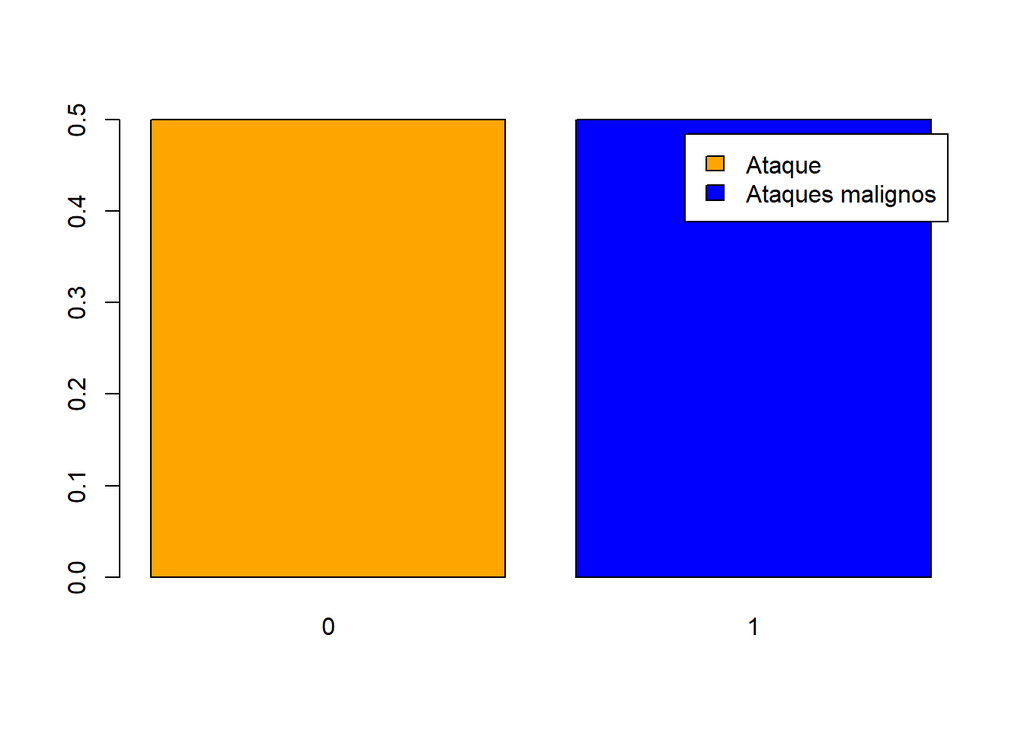

```r
barplot(prop.table(table(db$Label)),col=c("orange","blue"),
        legend.text=c("Ataque","Ataques malignos"))
```

*** Como se observa en la grafica anterior los datos se encuentran debidamente balanceados, ahora veremos que columnas nos son de utilidad.

Para verificar que columnas podemos usar, existe el metodo de determinar la correlacion entre la variable a predecir con otras columnas, donde si se obtiene una correlacion positiva significa que esa columna tienda a crecer junto con la variable de ataque.

```r
db$Label<-as.numeric(db$Label)
cor(db$L4_SRC_PORT,db$Label)
```

```
## [1] -0.3238299
```

Como se observa la columna de L4_SRC_PORT no fue una buena variable a comparar debido que obtuvo un resultado negativo.

```r
# cor(db$L4_DST_PORT,db$Label)
# cor(db$PROTOCOL,db$Label)
# cor(db$TCP_FLAGS,db$Label)

df <- db[,-c(1,3,41,40)]


for (i in colnames(df)){
  print(i)
  print(cor(df[[i]],db$Label))
}
```

```
## [1] "L4_SRC_PORT"
## [1] -0.3238299
## [1] "L4_DST_PORT"
## [1] -0.1085585
## [1] "PROTOCOL"
## [1] 0.05332642
## [1] "L7_PROTO"
## [1] 0.4449325
## [1] "IN_BYTES"
## [1] -0.004066038
## [1] "IN_PKTS"
## [1] -0.001139084
## [1] "OUT_BYTES"
## [1] -0.01320318
## [1] "OUT_PKTS"
```

[output cut: 59 more lines]

Tras obtener la correlacion con todas las variables se determino que las variables mas aceptables son, DST_TO_SRC_SECOND_BYTES,SHORTEST_FLOW_PKT, MAX_TTL,PROTOCOL,L7_PROTO,FLOW_DURATION_MILLISECONDS, DURATION_IN, DURATION_OUT y MIN_TTL. En base esto crearemos un nuevo dataframe para deteminar si el modelo es capaz de predicir el tipo de ataque.

```r
data<-db[,c("DST_TO_SRC_SECOND_BYTES","SHORTEST_FLOW_PKT","MAX_TTL","PROTOCOL","L7_PROTO","FLOW_DURATION_MILLISECONDS","DURATION_IN","DURATION_OUT","MIN_TTL","Label")]

data$Label<-as.factor(data$Label)
str(data)
```

```
## 'data.frame':    50330590 obs. of  10 variables:
##  $ DST_TO_SRC_SECOND_BYTES   : num  40 40 40 120 132 ...
##  $ SHORTEST_FLOW_PKT         : int  40 40 40 40 40 40 40 70 71 71 ...
##  $ MAX_TTL                   : int  0 0 0 128 64 100 0 0 128 0 ...
##  $ PROTOCOL                  : int  6 6 6 6 6 6 6 17 17 17 ...
##  $ L7_PROTO                  : num  0 0 0 91 0 ...
##  $ FLOW_DURATION_MILLISECONDS: int  0 0 0 0 0 0 0 0 0 0 ...
##  $ DURATION_IN               : int  0 0 0 0 0 0 0 0 0 0 ...
##  $ DURATION_OUT              : int  0 0 0 0 0 0 0 0 0 0 ...
##  $ MIN_TTL                   : int  0 0 0 128 64 100 0 0 128 0 ...
##  $ Label                     : Factor w/ 2 levels "1","2": 1 1 1 1 1 1 1 1 1 1 ...
```

#### Prediccion usando SVM

```r
#Shuffle data
data<-data[sample(1:nrow(data)), ]
#SVM
#Indicamos el porcentaje de entranamiento
porcentaje<-0.7

#Datos de entrenamiento y prueba
corte <- sample(nrow(data),nrow(data)*porcentaje)
train<-data[corte,]
test<-data[-corte,]

modelosvm<-svm(Label~., data = train[1:100000, ])
summary(modelosvm)
```

```
##
## Call:
## svm(formula = Label ~ ., data = train[1:1e+05, ])
##
##
## Parameters:
##    SVM-Type:  C-classification
##  SVM-Kernel:  radial
##        cost:  1
##
## Number of Support Vectors:  21352
##
##  ( 10673 10679 )
##
##
## Number of Classes:  2
##
## Levels:
##  1 2
```

#### Precision del modelo SVM

```r
predi<-predict(modelosvm,test[1:100000, ])
confusionMatrix(data[1:100000, ]$Label,predi)
```

```
## Confusion Matrix and Statistics
##
##           Reference
## Prediction     1     2
##          1 27477 22597
##          2 27425 22501
##
##                Accuracy : 0.4998
##                  95% CI : (0.4967, 0.5029)
##     No Information Rate : 0.549
##     P-Value [Acc > NIR] : 1
##
##                   Kappa : -6e-04
##
##  Mcnemar's Test P-Value : <2e-16
##
##             Sensitivity : 0.5005
##             Specificity : 0.4989
##          Pos Pred Value : 0.5487
##          Neg Pred Value : 0.4507
##              Prevalence : 0.5490
##          Detection Rate : 0.2748
##    Detection Prevalence : 0.5007
##       Balanced Accuracy : 0.4997
##
##        'Positive' Class : 1
##
```

#### Niave Bayes

```r
#Entrenar el modelo
modelo<-naiveBayes(Label~., data=train[1:100000, ])
#Realizamos la prediccion
predBayes<-predict(modelo, newdata =test[1:100000, ])
cm<-caret::confusionMatrix(as.factor(predBayes),as.factor(test[1:100000, ]$Label))
cm
```

```
## Confusion Matrix and Statistics
##
##           Reference
## Prediction     1     2
##          1  4453   175
##          2 45536 49836
##
##                Accuracy : 0.5429
##                  95% CI : (0.5398, 0.546)
##     No Information Rate : 0.5001
##     P-Value [Acc > NIR] : < 2.2e-16
##
##                   Kappa : 0.0856
##
##  Mcnemar's Test P-Value : < 2.2e-16
##
##             Sensitivity : 0.08908
##             Specificity : 0.99650
##          Pos Pred Value : 0.96219
##          Neg Pred Value : 0.52254
##              Prevalence : 0.49989
##          Detection Rate : 0.04453
##    Detection Prevalence : 0.04628
##       Balanced Accuracy : 0.54279
##
##        'Positive' Class : 1
##
```